# BIOST 561: Homework 2

Due date: 7:00pm on Monday, April 28nd, 2025

# Instructions

These instructions are essential, so please read them all carefully.

- Submit your homework on your GitHub page as the RMarkdown (`.Rmd`) and HTML files.
- Please answer the question prompt and show your code (inline). That is, all your code should be visible in the knitted chunks.
- To complete this homework, you may write in the `HW2.Rmd` file. (It is recommended to complete this homework in R Studio, where clicking the `Knit` button would knit your homework.)

# Disclosures

- Please disclose below who you collaborated with and if you’ve used ChatGPT (or any comparable AI tool) to what extent when completing this homework. See the syllabus for the course expectations.

I used chatgpt to modify ggplot code and to help me read what functions do.

(Hint: If you feel stuck in this homework, feel free to consult ChatGPT. Often, you need to double-check the responses from ChatGPT to verify its correctness. I would advise you to ask ChatGPT to generate minimal examples to demonstrate how to use various functions, as this will provide you with a clear example of how the function works.)

# Q0: Setting up your `UWBiost561` package

You do not need to write anything about any part of this question.

**Question 0A**: Install `tidyverse`. (This will involve typing `install.packages("tidyverse")` in the R console. You do not need to put this in your Markdown file.)

**Question 0B**: Update `DESCRIPTION` in your R package. That is, there is a file called `DESCRIPTION` in your `UWBiost561` package. It should look something like this:

```
Suggests:
  knitr,
  rmarkdown
```

Add the following lines to the `DESCRIPTION` to include `bookdown`, `tidyverse`, and `ggplot2`. It should look like something like:

```
Suggests:
  knitr,
  rmarkdown,
  bookdown,
  tidyverse,
  ggplot2
```

Save the file and close it.

**Question 0C**: Make sure you can load your package. (You need the `bookdown` package to knit the homework, similar to HW1.)

```r
library(bookdown)
library(tidyverse)
library(ggplot2)
```

(This might throw a warning about a “conflicted package.” You can ignore it.)

**Question 0D**: Double check the following things about your R package:

- Your `HW1.html`, `HW1.Rmd`, `HW2.Rmd` (this file), and your to-be-created `HW2.html` files are **only** in the `vignettes` folder of your R package. There is no `.gitignore` file in the `vignettes` folder. (Please delete the `.gitignore` file if one exists.)

# Q1: Practice using tibbles

**Intent**: This question is to give you some basic practice using tibbles (and the tidyverse way of analyzing data, overall).

For this question, we’ll be using two datasets that collect various statistics of countries over many years. The first dataset is the `gt` package (see https://search.r-project.org/CRAN/refmans/gt/html/countrypops.html), and has been formatted specifically for this homework. It can be loaded in the following code:

```r
country_population <- readr::read_csv("https://raw.githubusercontent.com/linnykos/561_s2025_public/main/HW2_files/country_population.csv")
country_population
```

```
#> # A tibble: 13,545 × 4
#>    iso3c country  year population
#>    <chr> <chr>   <dbl>      <dbl>
#>  1 ABW   Aruba    1960      54608
#>  2 ABW   Aruba    1961      55811
#>  3 ABW   Aruba    1962      56682
#>  4 ABW   Aruba    1963      57475
#>  5 ABW   Aruba    1964      58178
#>  6 ABW   Aruba    1965      58782
#>  7 ABW   Aruba    1966      59291
#>  8 ABW   Aruba    1967      59522
#>  9 ABW   Aruba    1968      59471
#> 10 ABW   Aruba    1969      59330
#> # ℹ 13,535 more rows
```

(Note that we’re reading the data using the `readr::read_csv` function, which automatically converts the `csv` data into a `tibble`. This is not the same as the `read.csv` function. See `?readr::read_csv` and `?read.csv`.) `country_population` contains the following columns:

- `iso3c`: Three-letter country code (see https://en.wikipedia.org/wiki/ISO_3166-1_alpha-3)
- `country`: Country name
- `year`: Year the statistic is collected
- `population`: Population, based on the World Bank estimate

The next dataset is from https://paldhous.github.io/NICAR/2017/r-analysis.html, and has also been formatted specifically for this homework. It can be loaded in the following code:

```r
country_birth <- readr::read_csv("https://raw.githubusercontent.com/linnykos/561_s2025_public/main/HW2_files/country_birth.csv")
country_birth
```

```
#> # A tibble: 5,486 × 5
#>    iso3c  year life_expect birth_rate neonat_mortal_rate
#>    <chr> <dbl>       <dbl>      <dbl>              <dbl>
#>  1 AND    1994          NA       10.9                3.2
#>  2 AND    1995          NA       11                  3
#>  3 AND    2006          NA       10.6                1.9
#>  4 AND    2007          NA       10.1                1.8
#>  5 AND    1996          NA       10.9                2.8
#>  6 AND    1993          NA       11.4                3.4
#>  7 AND    1997          NA       11.2                2.6
#>  8 AND    1998          NA       11.9                2.4
#>  9 AND    2008          NA       10.4                1.8
#> 10 AND    2009          NA        9.9                1.7
#> # ℹ 5,476 more rows
```

This question will allow you to practice basic data manipulation of these two `tibble` objects.

**Question 1A**: We will be manipulating the `country_population` data in this question. Your goal is the following: Select only rows for years between 1990 and 2010 (inclusive). Then, compute the mean population across all the years of a country for each country (defining a new variable called `mean_population`, via the `group_by()` and `summarize()` functions).

Figure 1 shows the first two rows of your desired output.

```r
pop1 = filter(country_population, year %in% c(1990:2010)) %>%
  group_by(iso3c,country) %>%
  summarize(
    mean_population = mean(population, na.rm = T)
  )
pop1
```

```
#> # A tibble: 215 × 3
#> # Groups:   iso3c [215]
#>    iso3c country              mean_population
#>    <chr> <chr>                          <dbl>
#>  1 ABW   Aruba                         85839.
#>  2 AFG   Afghanistan                19819866.
#>  3 AGO   Angola                     16829911.
#>  4 ALB   Albania                     3095489.
#>  5 AND   Andorra                       67825.
#>  6 ARE   United Arab Emirates        3858774.
#>  7 ARG   Argentina                  36972314.
#>  8 ARM   Armenia                     3211816.
#>  9 ASM   American Samoa                54995.
#> 10 ATG   Antigua and Barbuda           74385.
#> # ℹ 205 more rows
```

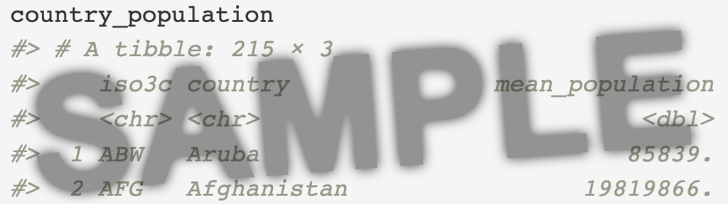

Figure 1: The output you are trying to reproduce (without the Sample watermark) in Question 1A.

**Question 1B**: We will be manipulating the `country_birth` data in this question. Your goal is the following: Select only rows for years between 1990 and 2010 (inclusive), keep the `iso3c`, `year`, `life_expect` columns, and then drop all rows with any `NA` in any of the 3 columns. Then, compute the minimum and maximum life expectancy (named as new columns called `min_life_expect` and `max_life_expect`) for each country across all the years (via the `summarize()` function), and finally, create a new column called `range_life_expect` that is the number of years between `min_life_expect` and `max_life_expect` for each country (via the `mutate()` function).

```r
birth1 = filter(country_birth, year %in% c(1990:2010)) %>%
  select(iso3c, year, life_expect) %>%
  filter(!is.na(iso3c),!is.na(year),!is.na(life_expect)) %>%
  group_by(iso3c) %>%
  summarize(
    min_life_expect = min(life_expect),
    max_life_expect = max(life_expect)
  ) %>%
  mutate(
    range_life_expect = max_life_expect - min_life_expect
  )
birth1
```

```
#> # A tibble: 203 × 4
#>    iso3c min_life_expect max_life_expect range_life_expect
#>    <chr>           <dbl>           <dbl>             <dbl>
#>  1 ABW              73.4            75.0              1.56
#>  2 AFG              49.9            59.0              9.11
#>  3 AGO              41.1            50.7              9.52
#>  4 ALB              71.9            77.0              5.14
#>  5 ARE              71.7            76.7              4.96
#>  6 ARG              71.5            75.5              3.94
#>  7 ARM              67.7            74.2              6.49
#>  8 ATG              71.2            75.3              4.15
#>  9 AUS              77.0            81.7              4.70
#> 10 AUT              75.6            80.6              5.01
#> # ℹ 193 more rows
```

Figure 2 shows the first two rows of your desired output.

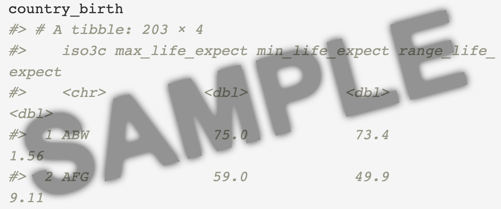

Figure 2: The output you are trying to reproduce (without the Sample watermark) in Question 1B.

**Question 1C**: We will now combine `country_population` and `country_birth` via a join. Specifically, using an `inner_join()` function, combine both these datasets by the `iso3c` variable, and call the new `tibble` object as `country_both`. Print out the first 10 rows of `country_both`. How many rows and columns are in `country_both`?

```r
country_both = inner_join(pop1, birth1, by = "iso3c")
country_both
```

```
#> # A tibble: 202 × 6
#> # Groups:   iso3c [202]
#>    iso3c country              mean_population min_life_expect max_life_expect range_life_expect
#>    <chr> <chr>                          <dbl>           <dbl>           <dbl>             <dbl>
#>  1 ABW   Aruba                         85839.            73.4            75.0              1.56
#>  2 AFG   Afghanistan                19819866.            49.9            59.0              9.11
#>  3 AGO   Angola                     16829911.            41.1            50.7              9.52
#>  4 ALB   Albania                     3095489.            71.9            77.0              5.14
#>  5 ARE   United Arab Emirates        3858774.            71.7            76.7              4.96
#>  6 ARG   Argentina                  36972314.            71.5            75.5              3.94
#>  7 ARM   Armenia                     3211816.            67.7            74.2              6.49
#>  8 ATG   Antigua and Barbuda           74385.            71.2            75.3              4.15
#>  9 AUS   Australia                  19200991.            77.0            81.7              4.70
#> 10 AUT   Austria                     8057573.            75.6            80.6              5.01
#> # ℹ 192 more rows
```

# Q2: Practice using ggplot via scatterplots and facets

**Intent**: This question is to give you some basic practice using ggplot, mainly plotting scatterplots and faceting the plots.

For this question, we’ll be using a dataset about the penguins from the Palmer Archipelago from https://allisonhorst.github.io/palmerpenguins/reference/penguins.html. We’ve processed it lightly for this homework.

```r
penguins <- readr::read_csv("https://raw.githubusercontent.com/linnykos/561_s2025_public/main/HW2_files/palmerpenguins.csv")
penguins
```

```
#> # A tibble: 333 × 8
#>    species island    bill_length_mm bill_depth_mm flipper_length_mm body_mass_g sex     year
#>    <chr>   <chr>              <dbl>         <dbl>             <dbl>       <dbl> <chr>  <dbl>
#>  1 Adelie  Torgersen           39.1          18.7               181        3750 male    2007
#>  2 Adelie  Torgersen           39.5          17.4               186        3800 female  2007
#>  3 Adelie  Torgersen           40.3          18                 195        3250 female  2007
#>  4 Adelie  Torgersen           36.7          19.3               193        3450 female  2007
#>  5 Adelie  Torgersen           39.3          20.6               190        3650 male    2007
#>  6 Adelie  Torgersen           38.9          17.8               181        3625 female  2007
#>  7 Adelie  Torgersen           39.2          19.6               195        4675 male    2007
#>  8 Adelie  Torgersen           41.1          17.6               182        3200 female  2007
#>  9 Adelie  Torgersen           38.6          21.2               191        3800 male    2007
#> 10 Adelie  Torgersen           34.6          21.1               198        4400 male    2007
#> # ℹ 323 more rows
```

You can see its original documentation for describing the variables in the dataset.

The following code makes a basic scatter plot. We will be improving this plot over the following sub-questions.

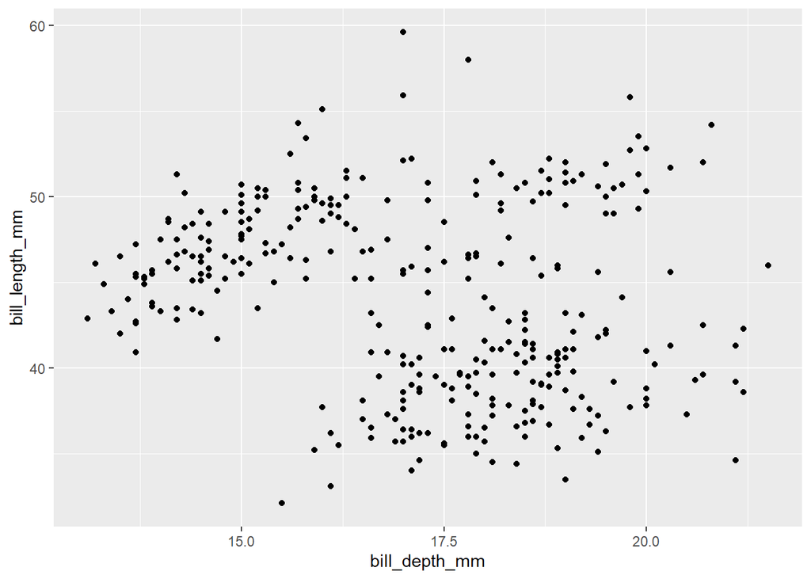

```r
penguins %>%
  ggplot(aes(x = bill_depth_mm, y = bill_length_mm)) +
  geom_point()
```

**Question 2A**: With the `penguins` dataset, change the x-axis label and y-axis label to say `Bill Depth (mm)` and `Bill length (mm)` respectively, as well as the title of the plot to write `Relation among ??? penguins`, where you use code to count how many rows there are in `penguins` automatically (in place of `???`). Additionally, color each point based on their `species`, where `Adelie` has the color `cornflowerblue`, `Chinstrap` has the color `coral2`, and `Gentoo` has the color `goldenrod3`.

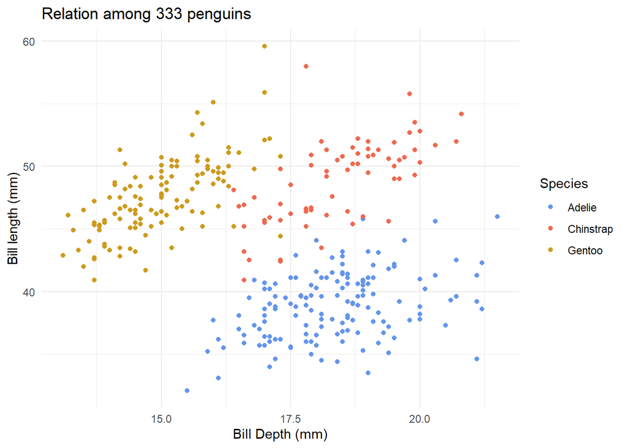

```r
penguins %>%
  ggplot(aes(
    x     = bill_depth_mm,
    y     = bill_length_mm,
    color = species
  )) +
  geom_point() +
  scale_color_manual(
    values = c(
      "Adelie"    = "cornflowerblue",
      "Chinstrap" = "coral2",
      "Gentoo"    = "goldenrod3"
    )
  ) +
  labs(
    x     = "Bill Depth (mm)",
    y     = "Bill length (mm)",
    color = "Species",
    title = paste0(
      "Relation among ",
      nrow(penguins),
      " penguins"
    )
  ) +
  theme_minimal()
```

(Hint: You will likely need the `scale_color_manual()`, `labs()`, and `paste()` functions.)

(You can see https://sites.stat.columbia.edu/tzheng/files/Rcolor.pdf to see where these color names come from.)

Figure 3 shows the plot you are trying to reproduce.

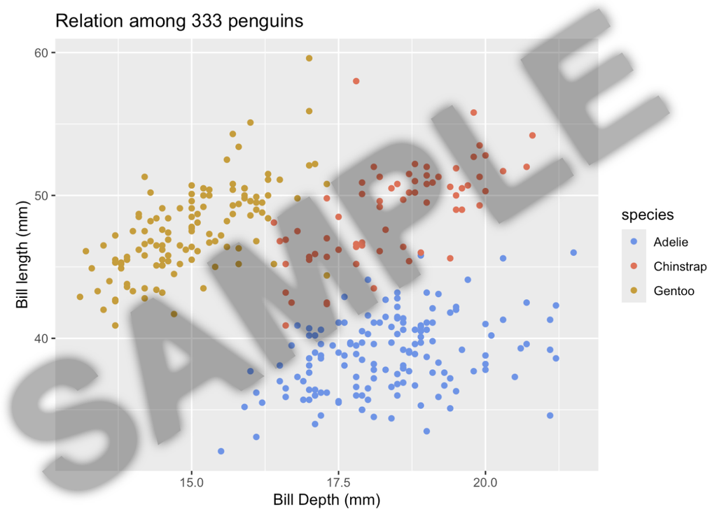

Figure 3: The plot you are trying to reproduce (without the Sample watermark) in Question 2A.

**Question 2B**: We now will make the following changes: 1) we will facet the scatterplot based on the `species`, 2) we will add a linear regression fit on each `species` (regression `bill_length_mm` onto the `bill_depth_mm`) and plot the linear regression fit, and 3) changing the transparency of the points to be 50% transparent (i.e., `alpha=0.5`).

(Hint: This question is a bit tricky since many things are going on. You will likely need the `geom_smooth()` and `facet_wrap()` functions.)

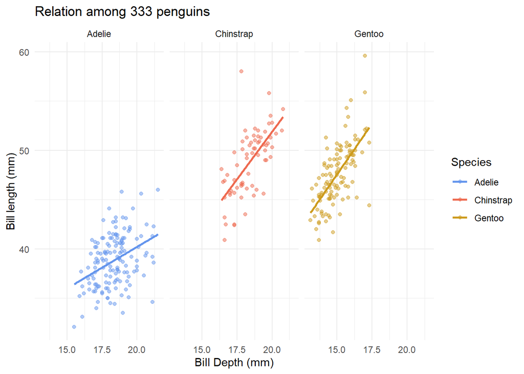

```r
penguins %>%
  ggplot(aes(
    x     = bill_depth_mm,
    y     = bill_length_mm,
    color = species
  )) +
  geom_point(alpha = 0.5) +
  geom_smooth(method = "lm", se = FALSE) +
  scale_color_manual(
    values = c(
      "Adelie"    = "cornflowerblue",
      "Chinstrap" = "coral2",
      "Gentoo"    = "goldenrod3"
    )
  ) +
  facet_wrap(~ species) +
  labs(
    x     = "Bill Depth (mm)",
    y     = "Bill length (mm)",
    color = "Species",
    title = paste0(
      "Relation among ",
      nrow(penguins),
      " penguins"
    )
  ) +
  theme_minimal()
```

Figure 4 shows the plot you are trying to reproduce.

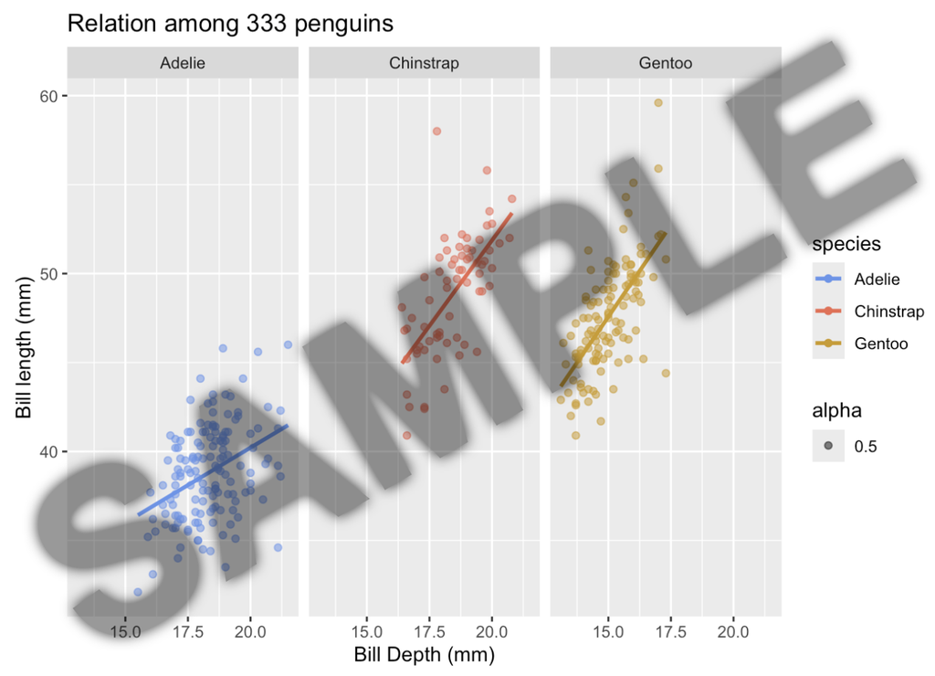

Figure 4: The plot you are trying to reproduce (without the Sample watermark) in Question 2B.

# Q3: Practice using ggplot via heatmaps

**Intent**: This question is to give you some basic practice using ggplot, mainly plotting heatmaps. You will also see this `generate_random_graph()` function again in future homeworks.

Run the following code to load the `generate_random_graph()`, which generates `adj_mat`, a random adjacency matrix (corresponding to a graph with 20 nodes). Each row/column of `adj_mat` corresponds to one of the 20 nodes, and a value of 0 or 1 denotes the lack or presence of an edge between two nodes, respectively.

```r
source("https://raw.githubusercontent.com/linnykos/561_s2025_public/main/HW2_files/random_graph_functions.R")
```

```r
set.seed(0)
result <- generate_random_graph(n = 20,
                                clique_fraction = 0.5,
                                density_low = 0.1)
adj_mat <- result$adj_mat
dim(adj_mat)
```

```
#> [1] 20 20
```

```r
adj_mat[1:5,1:5]
```

```
#>      [,1] [,2] [,3] [,4] [,5]
#> [1,]    1    0    1    0    0
#> [2,]    0    1    1    1    1
#> [3,]    1    1    1    0    0
#> [4,]    0    1    0    1    0
#> [5,]    0    1    0    0    1
```

**Question 3A**: Read how the provided `generate_random_graph()` works (either typing `generate_random_graph` into the R console or reading the code at https://raw.githubusercontent.com/linnykos/561_s2025_public/main/HW2_files/random_graph_functions.R). In three to five sentences, describe what `generate_random_graph()` does.

**Question 3B**: You will now write code to produce a heatmap to visualize `adj_mat`. Before this can happen, though, you need one more function to convert `adj_mat` into a “long form,” which is a necessity when visualizing any plot as a heatmap in ggplot. See https://r-graph-gallery.com/heatmap.html. This is done via the provided `pivot_longer_heatmap()` function:

```r
mat_long <- pivot_longer_heatmap(adj_mat)
mat_long
```

```
#> # A tibble: 400 × 3
#>        X     Y Value
#>    <int> <dbl> <dbl>
#>  1     1     1     1
#>  2     1     2     0
#>  3     1     3     1
#>  4     1     4     0
#>  5     1     5     0
#>  6     1     6     1
#>  7     1     7     0
#>  8     1     8     0
#>  9     1     9     0
#> 10     1    10     0
#> # ℹ 390 more rows
```

Read what the `pivot_longer_heatmap()` function does (either typing `pivot_longer_heatmap` into the R console or reading the code at https://raw.githubusercontent.com/linnykos/561_s2025_public/main/HW2_files/random_graph_functions.R). In three to five sentences, describe what `pivot_longer_heatmap()` does. Specifically, how does the output of `pivot_longer_heatmap()` relate to `adj_mat`? (Hint: For this question, it might be helpful to manually run the function line-by-line in your R console to see what each line of code does. The hardest part of this question will be understanding what the `pivot_longer` function does.

This function takes a square adjacency matrix, labels its rows and columns as nodes, and reshapes it into a three‑column table (X, Y, Value) where each row records the connection (0 or 1) between node X and node Y.

Look at the documentation of this function via `?tidyr::pivot_longer`. It might also be helpful to recall, in your R console, what the values of `adj_mat[1,1]`, `adj_mat[1,2]`, `adj_mat[1,3]`, … are. How do they look similar to rows in `mat_long`?)

**Question 3C**: Now you are ready to write code to visualize `mat_long` as a heatmap. Write code using ggplot’s functions to do this. You want to color all the `0` values as `palegoldenrod` and all the `1` values as `coral2`. Please set the aspect ratio of this plot to be 1:1 (i.e., your “boxes” are squares) via the `coord_fixed()` function.

In two to four sentences, describe how the plot you made relates to `adj_mat`.

(Hint: This question will be tricky, even though you need only roughly 7 functions. You likely want to use the `geom_tile()` and `scale_fill_manual()` functions.)

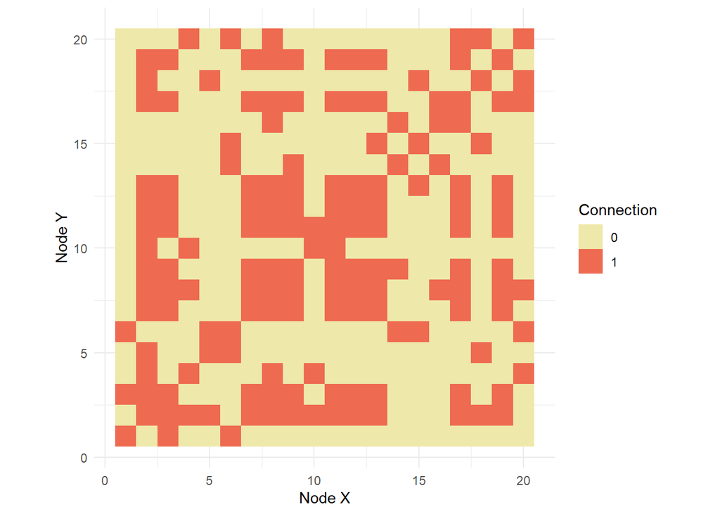

```r
ggplot(mat_long, aes(x = X, y = Y, fill = factor(Value))) +
  geom_tile() +
  scale_fill_manual(values = c("0" = "palegoldenrod", "1" = "coral2")) +
  coord_fixed() +
  theme_minimal() +
  labs(x = "Node X", y = "Node Y", fill = "Connection")
```

Figure 5 shows the plot you are trying to reproduce.

[figure not shown]

Figure 5: The plot you are trying to reproduce (without the Sample watermark) in Question 3C.

**Question 3D**: Congratulations! You have a working pipeline to visualize any adjacency matrix. For this last question, we will combine all your functions to visualize the following:

```r
adj_mat2 <- result$adj_mat[result$rev_order, result$rev_order]

mat_long2 <- pivot_longer_heatmap(adj_mat2)
mat_long2
```

```
#> # A tibble: 400 × 3
#>        X     Y Value
#>    <int> <dbl> <dbl>
#>  1     1     1     1
#>  2     1     2     1
#>  3     1     3     1
#>  4     1     4     1
#>  5     1     5     1
#>  6     1     6     1
#>  7     1     7     1
#>  8     1     8     1
#>  9     1     9     1
#> 10     1    10     1
#> # ℹ 390 more rows
```

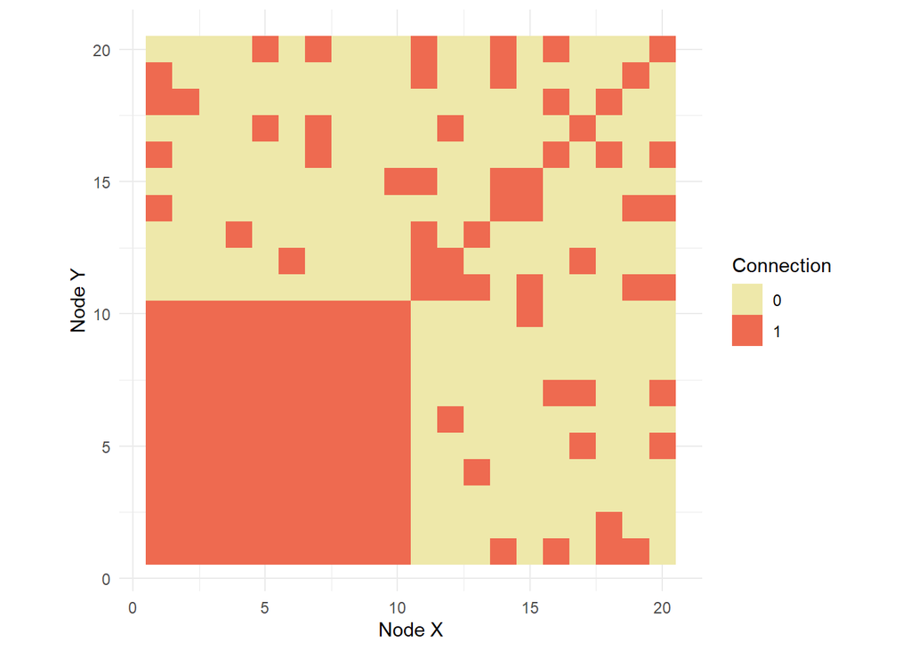

```r
ggplot(mat_long2, aes(x = X, y = Y, fill = factor(Value))) +
  geom_tile() +
  scale_fill_manual(values = c("0" = "palegoldenrod", "1" = "coral2")) +
  coord_fixed() +
  theme_minimal() +
  labs(x = "Node X", y = "Node Y", fill = "Connection")
```

You can double-check yourself to see that this line of code only permutes the rows and columns. The actual “graph” does not change (since the ordering of the rows/columns is arbitrary).

Use the provided `pivot_longer_heatmap()` function and your code from Question 3C to visualize `adj_mat2`. (You are mainly copy-pasting the code from your previous questions but now applying it to `adj_mat2`.)

You will see a dense set of red blocks in the bottom-left corner of the heatmap. In two sentences, what does this plot tell us about `adj_mat2`, and in turn, about `adj_mat`? (Hint: Question 4 will give you some context to answer this question.)

We can observe a dense block in the left corner, indicating a connected clique among the nodes of adj_mat2. This clique was also present in adj_mat but was spread.

Figure 6 shows the plot you are trying to reproduce.

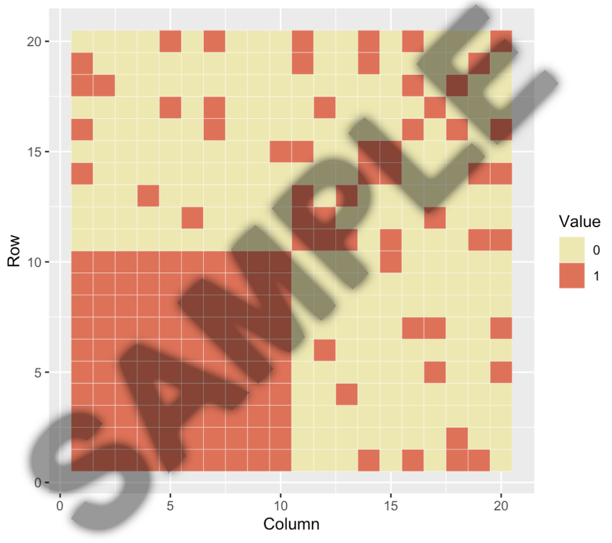

Figure 6: The plot you are trying to reproduce (without the Sample watermark) in Question 3D.

# Q4: Planning for the next homework – thinking how to test a function

**Intent**: This question will get you started on how to think about testing a function.

Question 3 demonstrates a “planted clique” – there might be a clique in a random graph (i.e., a collection of connected nodes). This clique might not be evident at first glance (as demonstrated in Question 3C), but when you permute the rows and columns (as done in Question 3D), the clique is quite apparent. (In Lecture 4, we will go over the basics of thinking about graphs and adjacency matrices. Please watch the Panopto recording on Canvas if you want some context.)

Suppose your teammate gave you a function to find the **maximal clique** in an adjacency matrix (i.e., the set of nodes that forms the largest clique). You are not told the typical size and characteristics of these adjacency matrices beforehand. Your job is to make sure this function is correct since you and your teammate are about to give this function to your manager, who will then give it to another division in your company to use. Your performance review will depend highly on whether or not other people in your company can reliably use your function.

In a short paragraph, write down ways to ensure your teammate’s function is “correct.” Please list at least four different ways you can test this function. You can interpret this notion of “correct” very liberally – this question is purposely framed to be open-ended.

(I am purposely not giving you the implementation of such a function. Please do not use ChatGPT for this specific question.)

(For those curious, this is the “Maximal Clique Problem” (MCP), which is a classic example of a “hard” problem in Computer Science theory. See https://arxiv.org/abs/2403.09742. You do not need to read this paper to complete this question – it’s simply for additional reading for curious students.)

1. Check for correctness: review that the input of the function is a matrix and the output is a matrix
2. Provide two matrices with different clique size and make sure the ouput is different
3. Check extreme cases: provide a matrix that does not have a clique and check if this is detected. As well as provide a matrix where everyone is conected and check the output.
4. Compare this function with other “validated” functions

# Q5: Feedback (Optional)

This “question” is an additional way for students to communicate with instructors. You could include positive feedback about topics you enjoyed learning in this module, critiques about the course difficulty/pacing, or some questions/confusions you had about course material. Your feedback can help shape the course for the rest of this quarter and future years. Please be mindful and polite when providing feedback. You may leave this question blank.

I have enjoyed learning about how to test a function. I have done it in the past but never thought about it in a systematic way.